# IODS course project

Teemu Vahtola

# Introduction to Open Data Science - Course Project

# About the project

This is the project page for the [Introduction to Open Data Science course](https://blogs.helsinki.fi/thinkopen/welcome-open-data-science/) of fall 2022. A link to the repository for this project page is here: [IODS-project (github.com/teemuvh/IODS-project)](https://github.com/teemuvh/IODS-project).

During this course, we get acquainted with R and certain data science methods, such as linear and logistic regression, clustering and classification algorithms, and dimensionality reduction models. During this course, we use the textbooks (1) Vehkalahti, Kimmo & Everitt, Brian S. (2019). *Multivariate Analysis for the Behavioral Sciences* and [(2)](https://argoshare.is.ed.ac.uk/healthyr_book/) Ewen Harrison and Riinu Pius (2021). *R for Health Data Science.*

### Week 1: Start me up!

During the first week, the focus is on getting everything up and running, and getting familiar with the syntax of R before moving to the more challenging topics of the course.

I use Python in my daily work, but so far I like how simple it is to read data into R.

```r
# Here, we could load a csv-file to R as follows:
# data <- read_csv("some_data.csv")
# And view it as follows:
# View(data)
# But since we do not have "some_data" at our disposal,
# I have just added this as a comment.

# However, we can print the date:
date()
```

```
## [1] "Wed Nov 23 14:42:30 2022"
```

The Harrison & Pius book seems to work well for revising R syntax as well as learning some new tricks already for data transformations (*mutate()*, *summarise()*, *pivot_wider()*, *factor()*, etc.) The difficult part will be remembering when to utilise these functions…

In the Vehkalahti & Everitt textbook chapters 1 and 2, I liked how the same data were presented in different visualisation formats, which made me reflect a lot about how I could have presented some of my data before. I will attempt to use this information in the future to actually focus a bit more on what could be an optimal visualisation method for some given data that I work with. Additionally, it was fun to get to draw different visualisations with R, and again it seems simpler compared to Python. In terms of how the material works as a “crash course” to R, I think that having a background in programming helps in getting started with the material, since it makes the programming part a bit easier. I believe the material could work if one comes with no background in programming, but the learning curve is a bit steeper in the beginning.

It is nice to get to refresh my memory with the statistical methods as well. I have taken an introductory course to statistics but it was many years ago, so I have to recap/re-learn many of the topics. Thus, my favourite part of this week has been to actually refreshing my memory on these topics in statistics and I expect to learn a lot especially with respect to this field. I believe this information will be useful for me in the future in my own research.

# Regression and model validation

*Jump straight to the assignments.*

```r
date()
```

```
## [1] "Wed Nov 23 14:42:30 2022"
```

The core idea of regression analysis is to use statistical methods to assess the way in which a change in circumstances affect variation in an observed random variable. This section summarises my notes for the chapters regarding *Simple linear regression* and *Multiple linear regression*.

There are four basic assumptions in linear regression:

1. The relationship between predictors and outcome is linear
2. The residuals are independent
3. The residuals are normally distributed
4. The residuals have equal variance

### Simple linear regression

Simple linear regression model (intercept $\beta_0$ is not always needed), has only a single explanatory variable ($x$) and a single dependent variable ($y$):

$$y_i = \beta_0 + \beta_1 x_i + \epsilon_i$$

where $\beta_0$ is the intercept, $\beta_1$ is the slope of the linear relationship between the dependent variable and the explanatory variable, and $\epsilon$ is an error term that measures the difference between the observed value and the prediction from the model.

The prediction of the model is presented without the loss term as:

$$\hat{y} = \beta_0 + \beta_1 x_i$$

This equation can then be used for predicting the value of a dependent variable for some explanatory variable.

The variability of the dependent by Regression Means Square (RGMS) and Residual Mean Square (RMS):

$$RGMS = \sum_{i=1}^{n} (\hat{y_i} - \overline{y}_i)^2$$
$$RMS = \sum_{i=1}^{n} \frac{(y_i - \hat{y_i})^2}{(n-2)}$$

#### Regression diagnostics

We can assess our model by calculating the difference between an observed value and our prediction:

$$\hat{\epsilon} = y - \hat{y}$$

R prints another measure for assessing how close the data are to the fitted line, R-squared:

$$R^2 = 1 - \frac{\sum_{i=1}^{n}(y - \hat{y})^2}{\sum_{i=1}^{n}(y -
\overline{y})^2}$$
where $\overline{y}$ is the mean value of the sample. R-squared represents the proportion of the dependent variable which is explained by the explanatory variable. If R-squared is 0.0, then the explanatory variable has no effect on the dependent variable. 1.0 indicates that all of the variability is explained by the model (i.e., the regression line fits perfectly). The adjusted R-squared includes a penalty term that lowers the value for less important explanatory variables.

And we should also use visualisation to assess the model; useful plots include:

- Boxplot (or a Q-Q plot) of the residuals
- Residuals against the corresponding values of the explanatory variables
- Residuals against the fitted values of the response variable

We can decide whether a linear model is appropriate or we should use a non-linear model.

### Multiple linear regression

Here, we have more explanatory variables than in the simple regression (e.g., analysing change in blood pressure based on coffee consumption on smokers and non-smokers). Basically, we have multiple parameters that effect the prediction.

$$\hat{y} = \beta_0 + \beta_1 x_1 + \beta_2 x_2$$

**Confounding** is a concept referring to a situation where another explanatory variable distorts the relationship between an explanatory variable and the outcome (e.g., smoking could be related to coffee consumption and to blood pressure).

### Assignments

#### 1. Data wrangling

Done and wrangled data in my GitHub [repo](https://github.com/teemuvh/IODS-project/tree/master/data).

#### 2. Regression analysis

**Task 1:**

First, we need to read the data we created in the data wrangling exercise. The data is stored in the **data** dictionary. Then we quickly check the structure and the dimensions of the data.

```r
learning2014 <- read.table("data/learning2014.csv", sep=",", header=T)

dim(learning2014)
```

```
## [1] 166   7
```

```r
str(learning2014)
```

```
## 'data.frame':    166 obs. of  7 variables:
##  $ gender  : chr  "F" "M" "F" "M" ...
##  $ age     : int  53 55 49 53 49 38 50 37 37 42 ...
##  $ attitude: num  3.7 3.1 2.5 3.5 3.7 3.8 3.5 2.9 3.8 2.1 ...
##  $ deep    : num  3.58 2.92 3.5 3.5 3.67 ...
##  $ stra    : num  3.38 2.75 3.62 3.12 3.62 ...
##  $ surf    : num  2.58 3.17 2.25 2.25 2.83 ...
##  $ points  : int  25 12 24 10 22 21 21 31 24 26 ...
```

`dim()` outputs the dimensionality of the data ([166, 7]), whereas `str()` outputs, in addition to the number of observations and variables (i.e., dimensions), a little more information about the data. `str()` also outputs a few examples of the observations in the seven variables.

The variables in the data are *gender*, *age*, *attitude*, *deep*, *stra*, *surf*, and *points*. I think that in general, this data is about students’ attitudes towards studying statistics and how they feel about learning the topics on some statistics course. The different variables indicate a student’s gender, the age of the student, student’s attitude towards statistics (averaged over 10 answers to questions on a Likert scale). From the [link](http://www.helsinki.fi/~kvehkala/JYTmooc/JYTOPKYS3-meta.txt) given in the material, I interpret that Deep, strategic (stra), and surface (surf) indicate learning methods based on some clusters of questions related to these methods. Points indicates the points a student got from the course exam. In the dataset considered in this exercise, we have the previous variables for 166 students.

**Task 2:**

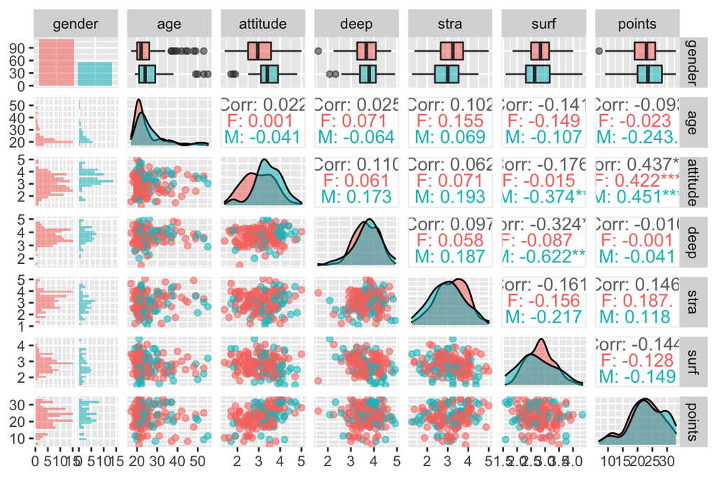

```r
# access the GGally and ggplot2 libraries
library(GGally)
library(ggplot2)

# create a plot matrix with ggpairs()
p <- ggpairs(learning2014, mapping = aes(col=gender, alpha=0.3), lower = list(combo = wrap("facethist", bins = 20)))

# draw the plot
p
```

I summarised the data to one scatterplot matrix From this visualisation above, we can observe different dimensions and how they interact. Scatterplots are drawn on the left side of the diagonal, the diagonal depicts the variable distribution, whereas the right side of the matrix displays the Pearson correlation.

First, we see that the sample has quite a lot more female students than males. Most of the students in both group were around the age of 20-25. Male students seem to have had slightly more positive attitude towards statistics, having most of the mass in the middle of the Likert scale (around 3.5), but also more answers in the higher end of the scale compared to female students. Male students seem to have had a bit stronger tendency towards *deep* learning strategy, whereas female students seem to have been more prone to the *strategic* dimension. Female students also seem to have been more prone to this *surface* dimension. Points in the exam seem quite similarly distributed between the groups. However, it seems that more male students have acquired the highest points.

Most of the variables seem not to be correlated based on the Pearson correlation coefficient. However, a few of them are. Quite understandably, attitude seems to correlate with the points acquired.

**Task 3:**

Now, we look at multivariable regression. Let the first explanatory variable be **attitude**, the second variable can be **stra**, and the third one **surf**. The decided variables are based on their correlation indicated by the Pearson correlation coefficient in the visualisation above.

We can first visualise all of the variables relationship with the exam scores independently:

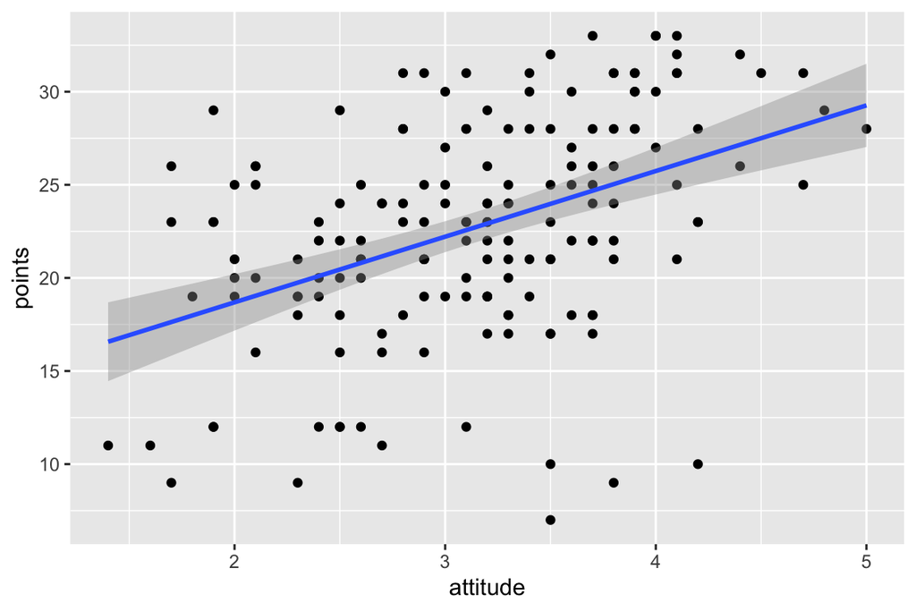

```r
library(ggplot2)
qplot(attitude, points, data = learning2014) + geom_smooth(method = "lm")
```

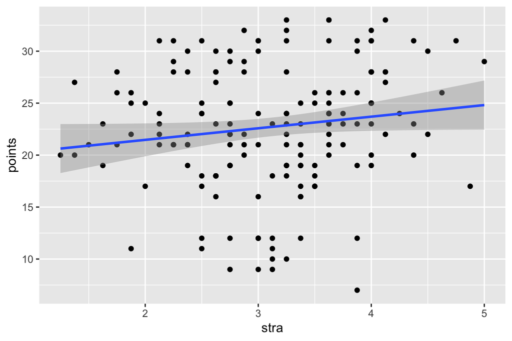

```r
library(ggplot2)
qplot(stra, points, data = learning2014) + geom_smooth(method = "lm")
```

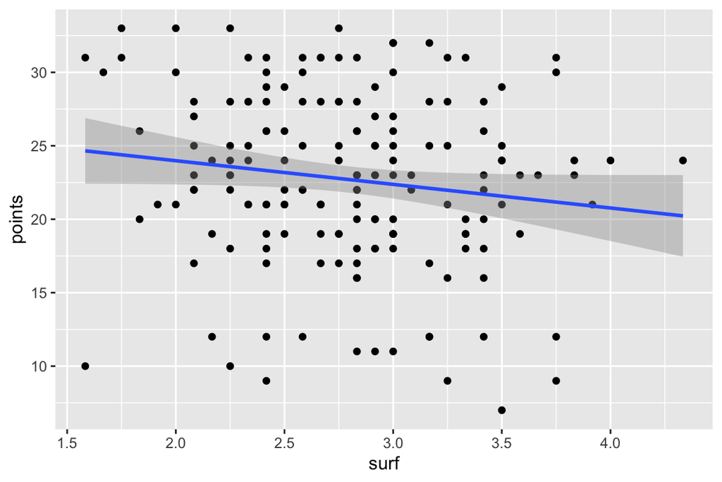

```r
library(ggplot2)
qplot(surf, points, data = learning2014) + geom_smooth(method = "lm")
```

Based on the three visualisations, it seems that both **attitude** and **stra** have a positive correlation with the exam results. **Surf**, unsurprisingly, seems to have a slightly negative correlation. Next, we fit a multivariable regression model to the given explanatory variables.

```r
# create a regression model with multiple explanatory variables
multivariable_model <- lm(points ~ attitude + stra + surf, data = learning2014)

# summary
multivariable_model %>%
  summary()
```

```
##
## Call:
## lm(formula = points ~ attitude + stra + surf, data = learning2014)
##
## Residuals:
##      Min       1Q   Median       3Q      Max
## -17.1550  -3.4346   0.5156   3.6401  10.8952
##
## Coefficients:
##             Estimate Std. Error t value Pr(>|t|)
## (Intercept)  11.0171     3.6837   2.991  0.00322 **
## attitude      3.3952     0.5741   5.913 1.93e-08 ***
## stra          0.8531     0.5416   1.575  0.11716
## surf         -0.5861     0.8014  -0.731  0.46563
## ---
## Signif. codes:  0 '***' 0.001 '**' 0.01 '*' 0.05 '.' 0.1 ' ' 1
##
## Residual standard error: 5.296 on 162 degrees of freedom
## Multiple R-squared:  0.2074, Adjusted R-squared:  0.1927
## F-statistic: 14.13 on 3 and 162 DF,  p-value: 3.156e-08
```

The summary includes residuals in five points (min, first quartile, median, third quartile, and max). If the model fits perfectly to the data, the distribution between the residuals should be symmetrical.

Next, there is the coefficients block with values for estimate, Std. error, t-value, and p-value.

The estimate column indicates that a change of one point in attitude results in a change of approximately 3.4 points in the exam scores. With respect to stra and surf, the correlation is one to 0.9 and one to -0.6 respectively.

The Std. error indicates how far the estimates are from the true average values of the dependent variables.

T-value indicates the distance of our coefficient estimates from 0 as standard deviations. This value can be positive or negative, but it should be far from 0. A large difference to 0 would indicate relationship between the given variables (e.g., attitude and points), whereas 0 (or near to 0) means that there is no relationship.

Finally, we have the probability of getting any value that is equal or larger than t. This value should be as small as possible for us to be able to confidently reject the null hypothesis.

The significant codes are probably in the output for a quicker read of the results.

Lastly, there are the residual standard error (RSE), multiple and adjusted R-squared, and F-statistics. The RSE measures how well the model fits the data based on the residuals ($y-\hat{y}$). In practice, it is the square root of the mean squared error (please, correct me if I am wrong):

$$RSE = \sqrt{\frac{1}{n}\sum_{i=1}^{n}(y_i - \hat{y_i})^2}$$
R-squared ($R^2$) is another value to assess how well the model fits the data. In practice, R-squared represents the proportion of the dependent variable which is explained by the explanatory variable. If R-squared is 0.0, then the explanatory variable has no effect on the dependent variable. If the result is 1.0, all of the variability is explained by the model (i.e., the regression line fits perfectly). The adjusted R-squared includes a penalty term that lowers the value for less important explanatory variables.

R-squared is calculated as:

$$R^2 = 1 - \frac{\sum_{i=1}^{n}(y - \hat{y})^2}{\sum_{i=1}^{n}(y -
\overline{y})^2}$$
where $\overline{y}$ is the mean value of the sample.

F-test compares the means of the groups and indicates whether at least one variable is statistically significant.

The summary of the model indicates that only **attitude** has a significant correlation with the exam points, whereas the correlations between **stra** and points and **surf** and points are not statistically significant. R-squared seems low to me. Perhaps this is because we only have so little data points to fit the model to?

Next, we remove the non-significant variables and fit the model again.

```r
# create a regression model with multiple explanatory variables
attitude_model <- lm(points ~ attitude, data = learning2014)

# summary
attitude_model %>%
  summary()
```

```
##
## Call:
## lm(formula = points ~ attitude, data = learning2014)
##
## Residuals:
##      Min       1Q   Median       3Q      Max
## -16.9763  -3.2119   0.4339   4.1534  10.6645
##
## Coefficients:
##             Estimate Std. Error t value Pr(>|t|)
## (Intercept)  11.6372     1.8303   6.358 1.95e-09 ***
## attitude      3.5255     0.5674   6.214 4.12e-09 ***
## ---
## Signif. codes:  0 '***' 0.001 '**' 0.01 '*' 0.05 '.' 0.1 ' ' 1
##
## Residual standard error: 5.32 on 164 degrees of freedom
## Multiple R-squared:  0.1906, Adjusted R-squared:  0.1856
## F-statistic: 38.61 on 1 and 164 DF,  p-value: 4.119e-09
```

Now, we only have the significant variable in the model.

**Task 4:**

Most of this task was done in the earlier task, but in short, a change of one point (on the Likert scale) in attitude results in a change of 3.5 points in the exam scores. R-squared was also explained above.

**Task 5:**

Finally, draw some visualisations of the residuals. First, I print the regression line of the attitude variable again, just to help in analysis:

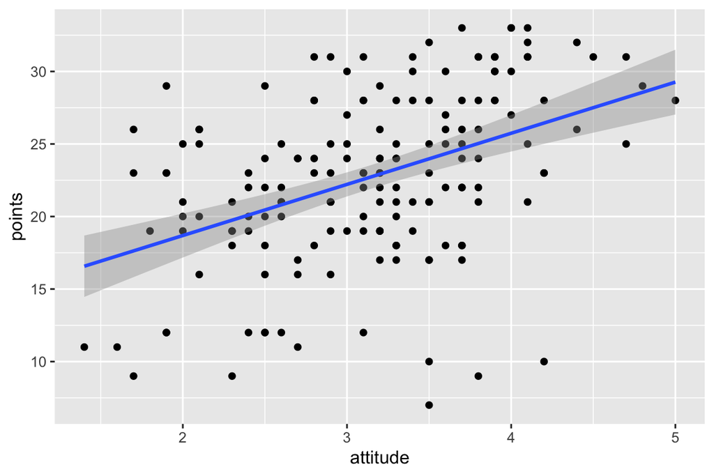

```r
library(ggplot2)
qplot(attitude, points, data = learning2014) + geom_smooth(method = "lm")
```

Next, I start outputting the different residual plots, beginning with *Residuals vs Fitted*.

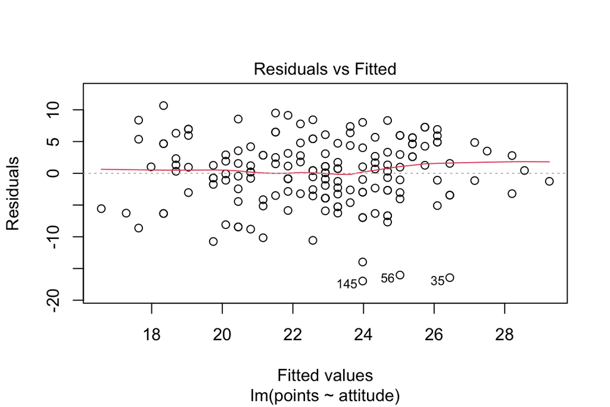

```r
# plot all plots:
# plot(attitude_model, which = c(1, 2, 5))
# but for the sake of the notebook, I plot these one by one
plot(attitude_model, which=1)
```

On the plot above, the residuals (y-axis) are plotted with respect to the estimated responses (x-axis). The residual line does not correspond exactly to the regression line. I think (but please correct me if I am wrong) what we can read from the line is that the variance is larger in the end of the data, meaning that the model might not have fitted well. This is likely an issue of small data size in this case.

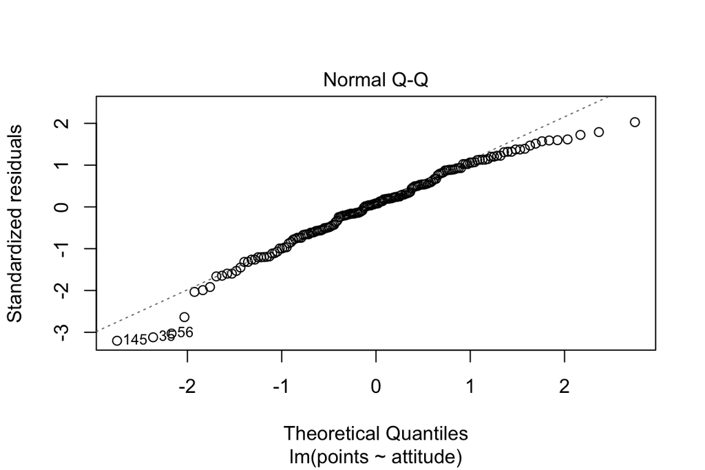

```r
plot(attitude_model, which=2)
```

The Q-Q plot shows that the data is not normally distributed, but skews in both ends of the data points. What I read from this is that there might be values in both ends that are very far from the expected mean if the data were normally distributed.

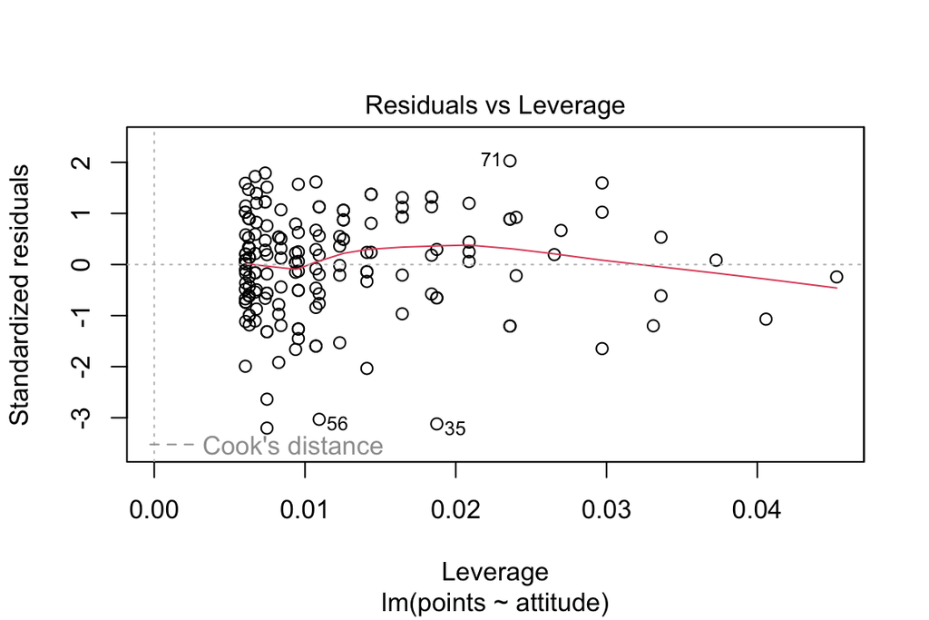

```r
plot(attitude_model, which=5)
```

Residuals vs Leverage shows how important different data points are to the regression model. The spread of the data points should not change as a function of leverage, but in the right end of the line it seems to change. Perhaps this is again an issue with small data size? There are no data points outside of Cook’s distance, so there are no data points whose deletion from the data would have a high influence on the regression model.

# Logistic regression

*Jump straight to the assignments.*

```r
date()
```

```
## [1] "Wed Nov 23 14:42:38 2022"
```

This part of the course will focus on Logistic Regression, which is a type of models where the output is categorical. For example, if we want to predict whether an email is spam or not, or whether a tumor is malign or benign, we could use a logistic regression model. Similarly, instead of only two, we could have multiple possible labels.

### Some notes about Logistic Regression

Linear regression models the population mean of the response variable directly as a linear function of the explanatory variables:

$$E(y|x_1, x_2, ..., x_n) = \beta_0 + \beta_1x_1 + \beta_2x_2 + ... +
\beta_nx_n$$

With classification of categorical values, this is not a suitable way, but we need to output something that we can interpret as probabilities for the different outcomes. The issue with linear regression models is that the output can be any real number between $-\infty$ and $\infty$. Thus, we need a *link* function, which here is the logarithm of the odds: $log(\frac{\pi}{1-\pi})$. Logistic regression then takes the form of:

$$logit (\pi) = log(\frac{\pi}{1-\pi}) = \beta_0 + \beta_1x_1 + \beta_2x_2
+ ... + \beta_nx_n$$

Logistic regression function rearraged is:

$$\pi = \frac{ \exp (\beta_0 + \beta_1x_1 + \beta_2x_2 + ... +
\beta_nx_n)}{1- \exp (\beta_0 + \beta_1x_1 + \beta_2x_2 + ... +
\beta_nx_n)}$$
Observed variable $y$ is represented as:

$$y = \pi(x_1, x_2, ..., x_n) + \epsilon$$
, where $\epsilon = 1 - \pi(x_1, x_2, ..., x_n)$, with probability $\pi(x_1, x_2, ..., x_n)$ if $y = 1$. Otherwise, if $y = 0$, $\epsilon = \pi(x_1, x_2, ..., x_n)$, with probability $1 - \pi(x_1, x_2, ..., x_n)$.

### Assignments

#### Data wrangling

Data for the following analysis exercise [here](https://github.com/teemuvh/IODS-project/blob/master/data/create_alc.R).

#### Logistic regression

In this assignment, we will apply logistic regression to the alcohol consumption data created in the previous exercise. The original data is presented in Cortez & Silva, (2008).[^1]

```r
library(readr)
alc <- read_csv("data/alc.csv", show_col_types = FALSE)
library(dplyr)
colnames(alc)
```

```
##  [1] "school"     "sex"        "age"        "address"    "famsize"
##  [6] "Pstatus"    "Medu"       "Fedu"       "Mjob"       "Fjob"
## [11] "reason"     "guardian"   "traveltime" "studytime"  "schoolsup"
## [16] "famsup"     "activities" "nursery"    "higher"     "internet"
## [21] "romantic"   "famrel"     "freetime"   "goout"      "Dalc"
## [26] "Walc"       "health"     "failures"   "paid"       "absences"
## [31] "G1"         "G2"         "G3"         "alc_use"    "high_use"
```

The wrangled data consists of 370 observations and 33 original variables. In practice, the observations are Portuguese secondary school students attending courses in mathematics and in Portuguese. The variables include student demographics, social and school related features, and grades. We have added another two variables, `alc_use` and `high_use`, where `alc_use` averages the weekday and weekend alcohol consumption, while `high_use` is a truth value indicating whether the students’ alcohol consumption is low (`FALSE`) or high (`TRUE`).

The goal of this exercise is to attempt at explaining the relationship between different explanatory variables to alcohol consumption. As there are so many options, we define the number of variables to be explored to four. There are many variables that I believe can explain alcohol consumption, but for this experiment, I will choose variables related to freetime activity. My hypothesis is that the more a student has ‘other’ activities (`internet`, `romantic`, `activities`) the less they have `freetime` and the less they consume alcohol.

First, we might need to change the string-formatted answers to integers.

```r
library(tidyverse)
library(finalfit)

alc <- alc %>%
  mutate(internet.int = factor(internet) %>%
           fct_recode("0" = "no",
                      "1" = "yes"),

         romantic.int = factor(romantic) %>%
           fct_recode("0" = "no",
                      "1"  = "yes"),

         activities.int = factor(activities) %>%
           fct_recode("0" = "no",
                      "1"  = "yes"),
  )
```

Next, let’s visualise the variables with respect to alcohol consumption.

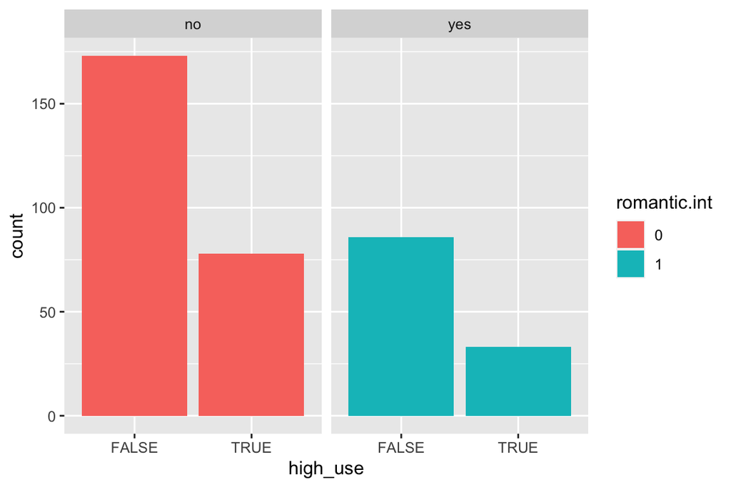

```r
# access the tidyverse packages dplyr and ggplot2
library(dplyr); library(ggplot2)

g1 <- ggplot(data = alc, aes(x = high_use, fill = romantic.int))
g1 + geom_bar() + facet_wrap("romantic")
```

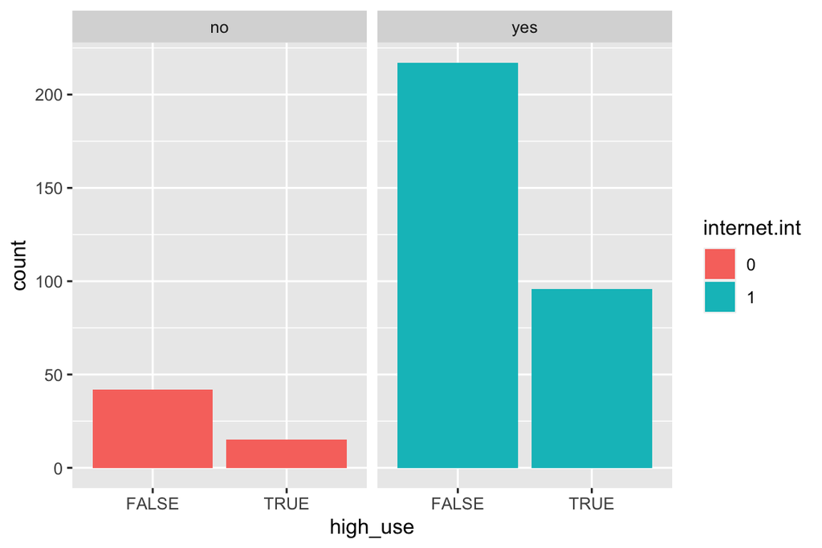

```r
g2 <- ggplot(data = alc, aes(x = high_use, fill = internet.int))
g2 + geom_bar() + facet_wrap("internet")
```

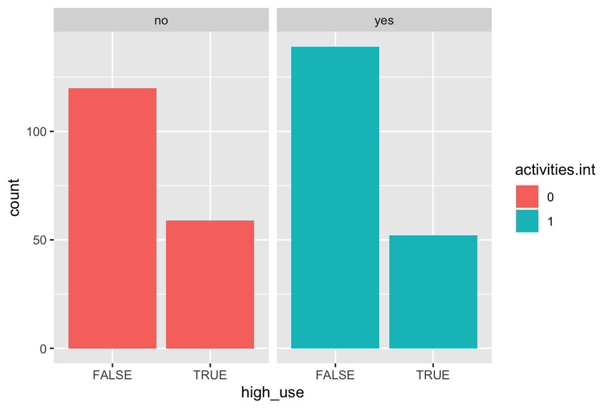

```r
g3 <- ggplot(data = alc, aes(x = high_use, fill = activities.int))
g3 + geom_bar() + facet_wrap("activities")
```

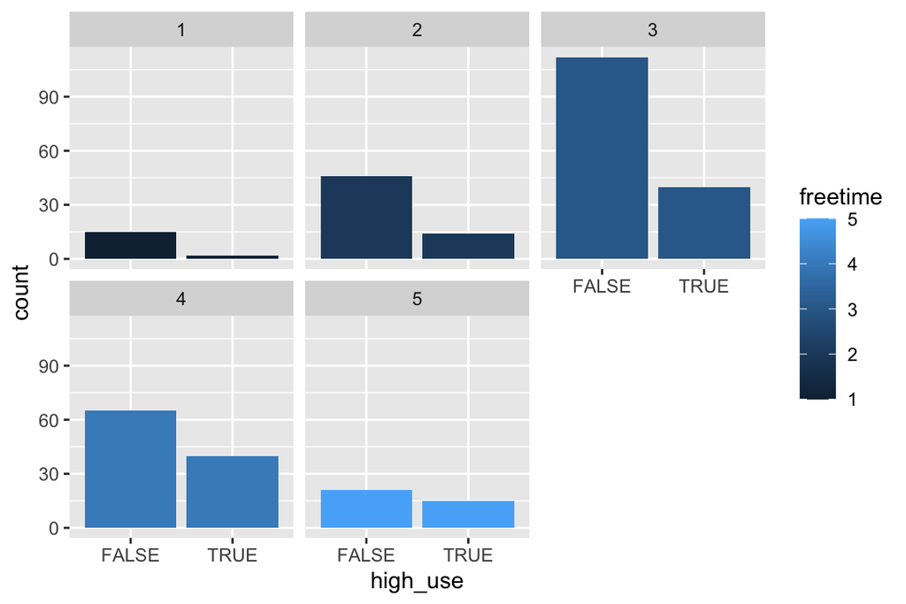

```r
g4 <- ggplot(data = alc, aes(x = high_use, fill = freetime))
g4 + geom_bar() + facet_wrap("freetime")
```

Based on the barplots, it seems that students who are in a romantic relationship are less prone to high usage of alcohol. Internet, however, does not show a similar effect. Rather, it seems that students who have internet connection at home seem to consume more alcohol. This is probably explained by the fact that not many households are without internet connection.

```r
library(dplyr)
alc %>%
  group_by(internet.int) %>%
  summarise(percent = 100 * n() / nrow(alc))
```

```
## # A tibble: 2 × 2
##   internet.int percent
##   <fct>          <dbl>
## 1 0               15.4
## 2 1               84.6
```

As it seems, there are approximately 85% of households with internet connection.

Extracurricular activities seem to not have a large effect on alcohol consumption, but perhaps students who have no extracurricular activities might be slightly more prone to high alcohol consumption.

Lastly, it seems that the more free time students have, the more the smaller the gap between high and low alcohol consumption.

Next, I use logistic regression to analyse the variables further, and see whether my hypothesis really holds.

```r
m <- glm(high_use ~ romantic.int + internet.int + activities.int + freetime, data = alc, family = "binomial")

summary(m)
```

```
##
## Call:
## glm(formula = high_use ~ romantic.int + internet.int + activities.int +
##     freetime, family = "binomial", data = alc)
##
## Deviance Residuals:
##     Min       1Q   Median       3Q      Max
## -1.2100  -0.8970  -0.7151   1.3130   1.9156
##
## Coefficients:
##                 Estimate Std. Error z value Pr(>|z|)
## (Intercept)      -2.0503     0.5010  -4.093 4.26e-05 ***
## romantic.int1    -0.1777     0.2510  -0.708  0.47882
## internet.int1     0.1793     0.3320   0.540  0.58925
## activities.int1  -0.3529     0.2329  -1.515  0.12983
## freetime          0.3895     0.1225   3.179  0.00148 **
## ---
## Signif. codes:  0 '***' 0.001 '**' 0.01 '*' 0.05 '.' 0.1 ' ' 1
##
## (Dispersion parameter for binomial family taken to be 1)
##
##     Null deviance: 452.04  on 369  degrees of freedom
## Residual deviance: 439.01  on 365  degrees of freedom
## AIC: 449.01
##
## Number of Fisher Scoring iterations: 4
```

Based on logistic regression, it seems that only `freetime` is statistically significant to high alcohol consumption.

```r
library(broom)
m %>%
  tidy(conf.int = TRUE, exp = TRUE)
```

```
## # A tibble: 5 × 7
##   term            estimate std.error statistic   p.value conf.low conf.high
##   <chr>              <dbl>     <dbl>     <dbl>     <dbl>    <dbl>     <dbl>
## 1 (Intercept)        0.129     0.501    -4.09  0.0000426   0.0466     0.334
## 2 romantic.int1      0.837     0.251    -0.708 0.479       0.508      1.36
## 3 internet.int1      1.20      0.332     0.540 0.589       0.635      2.35
## 4 activities.int1    0.703     0.233    -1.51  0.130       0.444      1.11
## 5 freetime           1.48      0.123     3.18  0.00148     1.17       1.89
```

Above, we have the coefficients (*estimate*) and the confidence intervals (*conf.low* and *conf.high*) for the different variables. For the only statistically significant explanatory variable is the amount of free time, I mostly focus on that. The coefficient, approx. 1.48, indicates that moving one step in freetime, 0 (very low) to 5 (very high), multiplies the odds of high alcohol consumption by 1.48. Or we can state that increase in freetime by one point increases the odds of high alcohol consumption by 48%. The negative coefficients (<1 in the tidy output) indicate that these explanatory variables (romantic relationship and extracurricular activities) have a decreasing effect on the risk of high alcohol consumption. I.e., if one is in a romantic relationship or has extracurricular activities, they are less prone for high alcohol consumption.

```r
m <- glm(high_use ~ freetime, data = alc, family = "binomial")
alc <- mutate(alc, probability = predict(m, type = "response"))
alc <- mutate(alc, prediction = probability > 0.5)

table(high_use = alc$high_use, prediction = alc$prediction)
```

```
##         prediction
## high_use FALSE
##    FALSE   259
##    TRUE    111
```

It seems that the model fitted only on `freetime` always predicts `FALSE`. We can calculate our model’s accuracy from the confusion matrix by:

$$acc = \frac{(TP + TN)}{(P + N)}$$

For our model, that would result in $acc = \frac{259}{370} = 0.7$

```r
# define a loss function (mean prediction error)
loss_func <- function(class, prob) {
  n_wrong <- abs(class - prob) > 0.5
  mean(n_wrong)
}

# call loss_func to compute the average number of wrong predictions in the (training) data
loss_func(class = alc$high_use, prob = alc$probability)
```

```
## [1] 0.3
```

Our loss function returns a loss of 0.3, indicating that, on average, we predict the wrong label by a probability of 30%.

```r
library(dplyr)
alc %>%
  group_by(high_use) %>%
  summarise(percent = 100 * n() / nrow(alc))
```

```
## # A tibble: 2 × 2
##   high_use percent
##   <lgl>      <dbl>
## 1 FALSE         70
## 2 TRUE          30
```

The data consists of 70% of `FALSE` labels. Thus, if we would always guess the majority class, like our model actually does, our baseline accuracy would be 0.7. Thus, any useful model should be able to obtain accuracy higher than that.

**Bonus exercise 1**

```r
m2 <- glm(high_use ~ sex + failures + absences + famrel + goout + health, data = alc, family = "binomial")
alc <- mutate(alc, probability = predict(m2, type = "response"))
alc <- mutate(alc, prediction = probability > 0.5)
```

```r
# K-fold cross-validation
library(boot)
cv <- cv.glm(data = alc, cost = loss_func, glmfit = m2, K = 10)

# average number of wrong predictions in the cross validation
cv$delta[1]
```

```
## [1] 0.2
```

I can get loss of approximately 0.2 in cross-validation by adding `sex`, `failures`, `absences`, `famrel`, `goout`, and `health` to the model features.

# Clustering and classification

*Jump straight to the assignments.*

```r
date()
```

```
## [1] "Wed Nov 23 14:42:41 2022"
```

This chapter focuses on a set of clustering methods, designed for visualizing and exploring statistical data. In general, we want to train a model that can position data points to different clusters (or groups) based on their characteristics. After the model is trained, it can be used for unseen data to classify that data to the learnt clusters. The most popular of these methods is **k-means clustering**.

### Assignments

(more chapters to be added similarly as we proceed with the course!)

[^1]: P. Cortez and A. Silva. Using Data Mining to Predict Secondary School Student Performance. In A. Brito and J. Teixeira Eds., Proceedings of 5th FUture BUsiness TEChnology Conference (FUBUTEC 2008) pp. 5-12, Porto, Portugal, April, 2008, EUROSIS, ISBN 978-9077381-39-7.